# Factor Analysis: "What influences love at first sight?"

# [3] rotation varimax

```r
fa(dating12, nfactors=5, rotate="varimax", fm="ml")
```

```
## Factor Analysis using method =  ml
## Call: fa(r = dating12, nfactors = 5, rotate = "varimax", fm = "ml")
## Standardized loadings (pattern matrix) based upon correlation matrix
##            ML3   ML2   ML4   ML5   ML1    h2     u2 com
## imprace   0.03 -0.05  0.09  0.25  0.00 0.073 0.9269 1.4
## imprelig -0.03 -0.05 -0.04  0.30 -0.04 0.096 0.9041 1.2
## date     -0.07 -0.03 -0.35  0.09 -0.02 0.138 0.8619 1.2
## go_out    0.02  0.02 -0.30 -0.01 -0.06 0.097 0.9033 1.1
## sports   -0.13  0.09  0.41 -0.16  0.01 0.214 0.7857 1.6
## tvsports -0.10  0.09  0.32  0.08 -0.13 0.143 0.8566 1.8
## exercise  0.00 -0.10  0.30  0.05  0.04 0.105 0.8951 1.3
## dining    0.39 -0.08  0.25  0.26  0.04 0.292 0.7077 2.7
## museums   0.92 -0.04 -0.04  0.00 -0.04 0.853 0.1467 1.0
## art       0.92 -0.04  0.01 -0.03 -0.05 0.843 0.1574 1.0
## hiking    0.22  0.06  0.03 -0.07  0.06 0.060 0.9401 1.5
## gaming   -0.05  0.15  0.23  0.09  0.02 0.085 0.9146 2.2
## clubbing  0.12 -0.05  0.26  0.09  0.03 0.091 0.9089 1.8
## reading   0.30 -0.01 -0.14  0.04  0.02 0.108 0.8917 1.5
## tv        0.02  0.01  0.08  0.50 -0.03 0.262 0.7383 1.1
## theater   0.57 -0.08 -0.09  0.37  0.00 0.482 0.5176 1.8
## movies    0.34  0.00 -0.03  0.37 -0.02 0.252 0.7481 2.0
## concerts  0.42 -0.03  0.07  0.21 -0.07 0.233 0.7671 1.6
## music     0.30 -0.02  0.19  0.22 -0.02 0.171 0.8292 2.6
## shopping  0.24 -0.17  0.26  0.45  0.01 0.353 0.6467 2.5
## yoga      0.30 -0.03  0.09  0.16 -0.03 0.127 0.8726 1.8
## exphappy  0.07  0.16  0.27 -0.05  0.06 0.109 0.8912 1.9
## attr1_1  -0.13 -0.35  0.44 -0.45 -0.12 0.555 0.4454 3.2
## sinc1_1  -0.01  0.18 -0.35  0.20  0.01 0.196 0.8040 2.2
## intel1_1  0.13 -0.06 -0.26  0.01 -0.02 0.089 0.9106 1.6
## fun1_1   -0.04  0.06  0.12 -0.05  0.30 0.114 0.8858 1.5
## amb1_1    0.11  0.16 -0.02  0.44  0.08 0.239 0.7606 1.5
## shar1_1   0.04  0.31 -0.27  0.25 -0.11 0.245 0.7552 3.3
## attr2_1   0.05 -0.94 -0.05  0.02 -0.32 0.995 0.0049 1.2
## sinc2_1  -0.07  0.67  0.04 -0.03 -0.01 0.452 0.5481 1.0
## intel2_1 -0.04  0.60  0.15 -0.10  0.00 0.391 0.6086 1.2
## fun2_1    0.04 -0.10 -0.11  0.04  0.99 0.995 0.0050 1.1
## amb2_1   -0.10  0.59  0.16 -0.15 -0.13 0.419 0.5811 1.5
## shar2_1   0.09  0.52 -0.14  0.22 -0.04 0.342 0.6576 1.6
## attr3_1   0.11  0.01  0.53  0.06  0.04 0.302 0.6978 1.1
## sinc3_1   0.11  0.03  0.05  0.27 -0.02 0.087 0.9133 1.4
```

[output cut: 17 more lines]

```
## The root mean square of the residuals (RMSR) is  0.07
## The df corrected root mean square of the residuals is  0.08
##
## The harmonic number of observations is  8191 with the empirical chi square  56272.09  with prob <  0
## The total number of observations was  8191  with Likelihood Chi Square =  80980.15  with prob <  0
##
## Tucker Lewis Index of factoring reliability =  0.251
## RMSEA index =  0.133  and the 90 % confidence intervals are  0.132 0.134
## BIC =  75970.16
## Fit based upon off diagonal values = 0.77
## Measures of factor score adequacy
##                                                    ML3  ML2  ML4  ML5  ML1
## Correlation of (regression) scores with factors   0.96 1.00 0.88 0.85 1.00
## Multiple R square of scores with factors          0.93 0.99 0.78 0.73 0.99
## Minimum correlation of possible factor scores     0.85 0.98 0.57 0.46 0.99
```

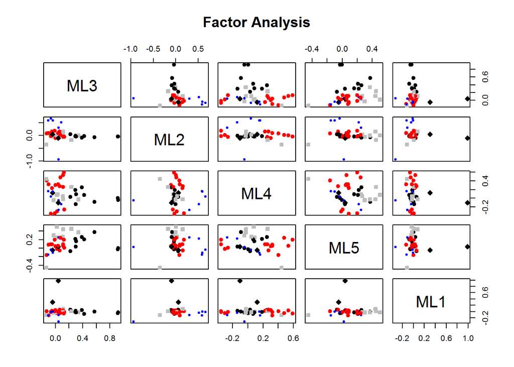

```r
factor.plot(fa(dating12, nfactors=5, rotate="varimax", fm="ml"))
```

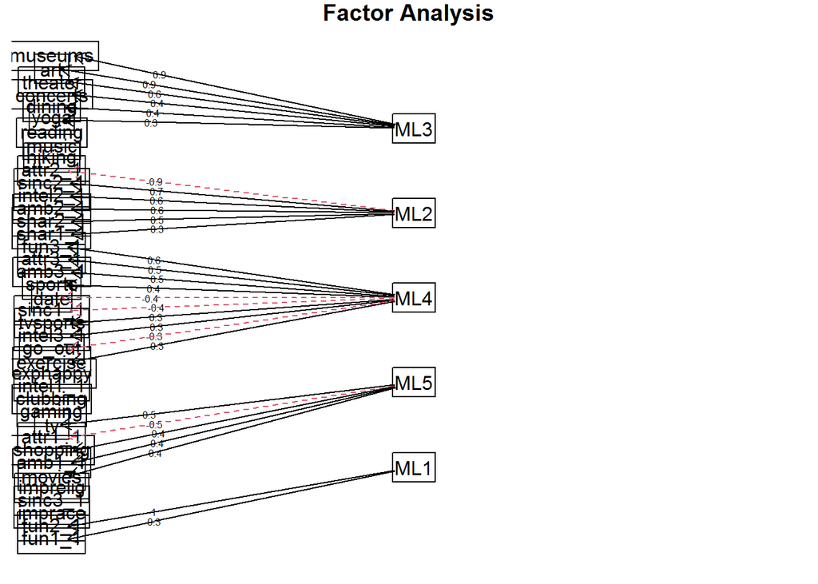

```r
fa.diagram(fa(dating12, nfactors=5, rotate="varimax", fm="ml"))
```

# [4] rotation oblimin

```r
library(GPArotation)

fa(dating12, nfactors=5, rotate="oblimin", fm="ml")
```

```
## Factor Analysis using method =  ml
## Call: fa(r = dating12, nfactors = 5, rotate = "oblimin", fm = "ml")
## Standardized loadings (pattern matrix) based upon correlation matrix
##            ML2   ML3   ML4   ML5   ML1    h2     u2 com
## imprace  -0.08 -0.05  0.21  0.18  0.01 0.073 0.9269 2.4
## imprelig -0.12 -0.12  0.11  0.29 -0.03 0.096 0.9041 2.0
## date     -0.11 -0.07 -0.27  0.23 -0.01 0.138 0.8619 2.5
## go_out   -0.03  0.05 -0.28  0.13 -0.06 0.097 0.9033 1.6
## sports    0.18 -0.10  0.27 -0.31 -0.02 0.214 0.7857 2.9
## tvsports  0.11 -0.13  0.31 -0.04 -0.15 0.143 0.8566 2.2
## exercise -0.05 -0.04  0.30 -0.10  0.06 0.105 0.8951 1.4
## dining   -0.06  0.29  0.37  0.11  0.06 0.292 0.7077 2.2
## museums   0.01  0.93 -0.03 -0.01  0.00 0.853 0.1467 1.0
## art       0.01  0.93  0.00 -0.06 -0.02 0.843 0.1574 1.0
## hiking    0.09  0.24  0.00 -0.08  0.05 0.060 0.9401 1.6
## gaming    0.17 -0.08  0.24  0.00 -0.01 0.085 0.9146 2.1
## clubbing -0.01  0.07  0.28 -0.05  0.04 0.091 0.9089 1.2
## reading  -0.02  0.29 -0.10  0.09  0.03 0.108 0.8917 1.4
## tv       -0.08 -0.14  0.32  0.44 -0.03 0.262 0.7383 2.1
## theater  -0.13  0.46  0.12  0.36  0.04 0.482 0.5176 2.2
## movies   -0.06  0.23  0.16  0.35 -0.01 0.252 0.7481 2.3
## concerts -0.04  0.36  0.17  0.15 -0.05 0.233 0.7671 1.9
## music    -0.01  0.22  0.28  0.11 -0.01 0.171 0.8292 2.3
## shopping -0.19  0.07  0.47  0.27  0.05 0.353 0.6467 2.1
## yoga     -0.03  0.25  0.16  0.10 -0.01 0.127 0.8726 2.1
## exphappy  0.22  0.07  0.21 -0.15  0.03 0.109 0.8912 3.0
## attr1_1  -0.20 -0.04  0.17 -0.65 -0.07 0.555 0.4454 1.4
## sinc1_1   0.08 -0.04 -0.22  0.36 -0.02 0.196 0.8040 1.8
## intel1_1 -0.10  0.14 -0.23  0.11 -0.01 0.089 0.9106 2.7
## fun1_1    0.13 -0.05  0.10 -0.11  0.29 0.114 0.8858 2.1
## amb1_1    0.08 -0.01  0.20  0.43  0.06 0.239 0.7606 1.5
## shar1_1   0.19  0.01 -0.13  0.40 -0.16 0.245 0.7552 2.0
## attr2_1  -0.97  0.00 -0.01 -0.07 -0.16 0.995 0.0049 1.1
## sinc2_1   0.66 -0.02 -0.01  0.05 -0.13 0.452 0.5481 1.1
## intel2_1  0.62  0.01  0.06 -0.08 -0.11 0.391 0.6086 1.1
## fun2_1    0.02 -0.01 -0.01 -0.01  1.00 0.995 0.0050 1.0
## amb2_1    0.60 -0.03  0.03 -0.12 -0.23 0.419 0.5811 1.4
## shar2_1   0.43  0.06 -0.04  0.34 -0.12 0.342 0.6576 2.1
## attr3_1   0.10  0.06  0.51 -0.19  0.03 0.302 0.6978 1.4
## sinc3_1  -0.01  0.03  0.17  0.23 -0.02 0.087 0.9133 1.9
```

[output cut: 25 more lines]

```
## The root mean square of the residuals (RMSR) is  0.07
## The df corrected root mean square of the residuals is  0.08
##
## The harmonic number of observations is  8191 with the empirical chi square  56272.09  with prob <  0
## The total number of observations was  8191  with Likelihood Chi Square =  80980.15  with prob <  0
##
## Tucker Lewis Index of factoring reliability =  0.251
## RMSEA index =  0.133  and the 90 % confidence intervals are  0.132 0.134
## BIC =  75970.16
## Fit based upon off diagonal values = 0.77
## Measures of factor score adequacy
##                                                    ML2  ML3  ML4  ML5  ML1
## Correlation of (regression) scores with factors   1.00 0.96 0.88 0.88 1.00
## Multiple R square of scores with factors          0.99 0.93 0.78 0.77 0.99
## Minimum correlation of possible factor scores     0.99 0.85 0.56 0.54 0.99
```

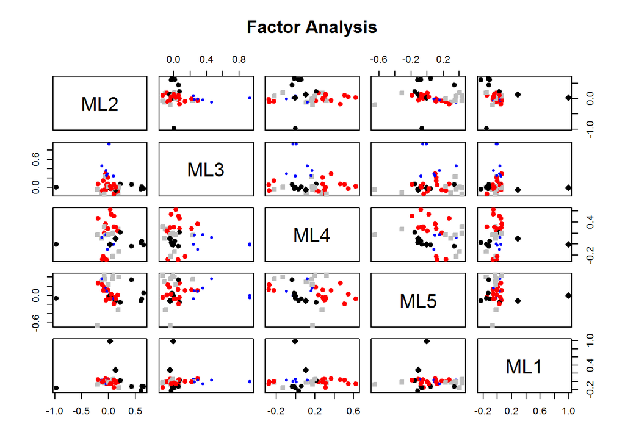

```r
factor.plot(fa(dating12, nfactors=5, rotate="oblimin", fm="ml"))
```

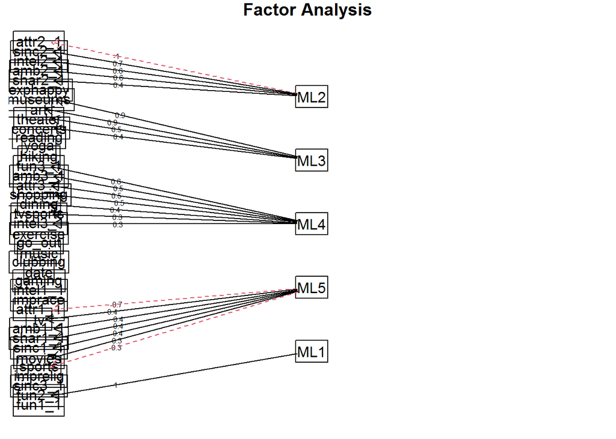

```r
fa.diagram(fa(dating12, nfactors=5, rotate="oblimin", fm="ml"))
```

I decided to choose [4] rotation oblimin factor analysis, because it seems to me as best one, since it distributes proportion var more equally then other models: 0.07 0.07 0.07 0.06 0.03

# Improvement

I think it is necessary to exclude some variables, that have highest uniqness (with rotation).

```r
dat<- dating[c( "sports", "tvsports", "exercise",  "dining" , "museums",  "art",
                   "tv",  "theater", "movies",  "concerts",
                   "music",   "shopping",  "exphappy" , "attr1_1",
                   "amb1_1", "shar1_1", "attr2_1", "sinc2_1",   "intel2_1",
                   "fun2_1",   "amb2_1",   "shar2_1",   "attr3_1",
                   "fun3_1",   "amb3_1")]




dat <- as.data.frame(dat)
dat <- na.omit(dat)
```

```r
library(nFactors)
op_fact <- eigen(cor(dat))
op_fact$values
```

```
##  [1] 3.862167342 2.816633848 2.567521298 1.659713487 1.507894142 1.324371378
##  [7] 1.229148076 1.110805165 1.030796509 0.859704566 0.794222565 0.750430380
## [13] 0.731522016 0.647040123 0.615034482 0.608671662 0.532921501 0.473601853
## [19] 0.444640930 0.400614786 0.316653090 0.299633377 0.274609935 0.134832741
## [25] 0.006814749
```

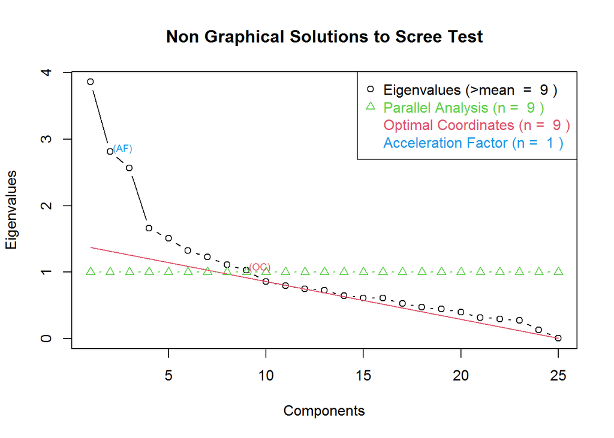

```r
op_plot <- nScree(x=op_fact$values)
plotnScree(op_plot)
```

So there is 9 values, that ara >1, so we need to take 9 factors.

```r
KMO(dat)
```

```
## Kaiser-Meyer-Olkin factor adequacy
## Call: KMO(r = dat)
## Overall MSA =  0.38
## MSA for each item =
##   sports tvsports exercise   dining  museums      art       tv  theater
##     0.63     0.60     0.66     0.83     0.68     0.70     0.55     0.86
##   movies concerts    music shopping exphappy  attr1_1   amb1_1  shar1_1
##     0.78     0.71     0.68     0.74     0.79     0.66     0.59     0.75
##  attr2_1  sinc2_1 intel2_1   fun2_1   amb2_1  shar2_1  attr3_1   fun3_1
##     0.26     0.14     0.11     0.05     0.12     0.13     0.69     0.74
##   amb3_1
##     0.69
```

Here overal MSA = 0.38. <0.5 that is not very good, but in general variables are higher than 0.5 exept some.

```r
fa(dat, nfactors=9, rotate="oblimin", fm="ml")
```

```
## Factor Analysis using method =  ml
## Call: fa(r = dat, nfactors = 9, rotate = "oblimin", fm = "ml")
## Standardized loadings (pattern matrix) based upon correlation matrix
##            ML6   ML8   ML9   ML7   ML5   ML3   ML1   ML4   ML2   h2    u2 com
## sports   -0.08  0.53 -0.27  0.09  0.04  0.07  0.02  0.03  0.01 0.37 0.632 1.7
## tvsports -0.12  0.34  0.02  0.12 -0.05  0.18  0.03 -0.01 -0.12 0.20 0.800 2.6
## exercise  0.01  0.42  0.01 -0.06  0.02 -0.07 -0.03 -0.03  0.05 0.18 0.816 1.2
## dining    0.29  0.20  0.32  0.01  0.01 -0.06 -0.07  0.05  0.04 0.30 0.697 3.0
## museums   0.96  0.00 -0.02 -0.02  0.00 -0.01  0.03 -0.01  0.00 0.89 0.108 1.0
## art       0.90  0.03 -0.03  0.04 -0.01  0.03 -0.02  0.00 -0.02 0.82 0.180 1.0
## tv       -0.15 -0.02  0.59  0.03 -0.01  0.07 -0.01 -0.03 -0.04 0.33 0.674 1.2
## theater   0.39 -0.15  0.34  0.17  0.05 -0.04 -0.10  0.01  0.02 0.51 0.488 2.9
## movies    0.10 -0.14  0.38  0.29 -0.01  0.02  0.00  0.00  0.00 0.35 0.654 2.3
## concerts  0.03 -0.05 -0.03  0.92 -0.01  0.00 -0.01  0.00 -0.01 0.85 0.145 1.0
## music    -0.03  0.13  0.04  0.71  0.04 -0.04  0.03 -0.01  0.03 0.53 0.475 1.1
## shopping  0.04  0.17  0.61  0.05 -0.07 -0.04 -0.06 -0.04  0.01 0.46 0.537 1.2
## exphappy  0.03  0.26 -0.05  0.14 -0.02  0.16  0.02  0.10  0.06 0.14 0.864 2.9
## attr1_1  -0.06  0.36 -0.28  0.04 -0.26 -0.09 -0.03 -0.09 -0.13 0.38 0.620 3.6
## amb1_1    0.04 -0.03  0.43 -0.10  0.13 -0.02  0.13  0.00  0.08 0.24 0.764 1.6
## shar1_1  -0.02 -0.24  0.05  0.07  0.41  0.09  0.05 -0.07 -0.10 0.28 0.721 2.1
## attr2_1   0.01 -0.01  0.02  0.01 -0.32 -0.38 -0.36 -0.34 -0.32 1.00 0.005 4.9
## sinc2_1   0.00  0.00  0.00 -0.01 -0.04  1.03 -0.04 -0.03 -0.05 1.00 0.005 1.0
## intel2_1 -0.01  0.00 -0.01  0.00 -0.05 -0.04 -0.03  1.03 -0.05 1.00 0.005 1.0
## fun2_1   -0.01  0.00  0.00  0.00 -0.06 -0.05 -0.06 -0.06  0.99 1.00 0.005 1.0
## amb2_1    0.00  0.00  0.00  0.00 -0.05 -0.04  1.02 -0.03 -0.06 1.00 0.005 1.0
## shar2_1   0.00  0.03 -0.01  0.01  1.01 -0.04 -0.05 -0.04 -0.05 0.97 0.031 1.0
## attr3_1   0.11  0.57  0.10 -0.08  0.09  0.00 -0.01  0.00  0.03 0.35 0.652 1.2
## fun3_1    0.04  0.53  0.24  0.05 -0.04  0.01  0.03  0.02 -0.06 0.38 0.620 1.5
## amb3_1    0.00  0.40  0.29  0.00  0.00 -0.03  0.09  0.02 -0.05 0.27 0.734 2.0
##
##                        ML6  ML8  ML9  ML7  ML5  ML3  ML1  ML4  ML2
## SS loadings           2.14 1.75 1.69 1.60 1.47 1.39 1.30 1.26 1.17
## Proportion Var        0.09 0.07 0.07 0.06 0.06 0.06 0.05 0.05 0.05
## Cumulative Var        0.09 0.16 0.22 0.29 0.35 0.40 0.45 0.50 0.55
## Proportion Explained  0.16 0.13 0.12 0.12 0.11 0.10 0.09 0.09 0.09
## Cumulative Proportion 0.16 0.28 0.41 0.52 0.63 0.73 0.82 0.91 1.00
##
##  With factor correlations of
##       ML6   ML8   ML9   ML7   ML5   ML3   ML1   ML4   ML2
## ML6  1.00 -0.02  0.28  0.40  0.06 -0.09 -0.12 -0.07  0.00
```

[output cut: 19 more lines]

```
## The total number of observations was  8209  with Likelihood Chi Square =  10707.03  with prob <  0
##
## Tucker Lewis Index of factoring reliability =  0.689
## RMSEA index =  0.108  and the 90 % confidence intervals are  0.106 0.11
## BIC =  9706.59
## Fit based upon off diagonal values = 0.94
## Measures of factor score adequacy
##                                                    ML6  ML8  ML9  ML7  ML5  ML3
## Correlation of (regression) scores with factors   0.97 0.85 0.85 0.94 0.99 1.00
## Multiple R square of scores with factors          0.93 0.72 0.73 0.88 0.98 1.00
## Minimum correlation of possible factor scores     0.86 0.45 0.45 0.76 0.96 0.99
##                                                    ML1  ML4  ML2
## Correlation of (regression) scores with factors   1.00 1.00 1.00
## Multiple R square of scores with factors          1.00 1.00 1.00
## Minimum correlation of possible factor scores     0.99 0.99 0.99
```

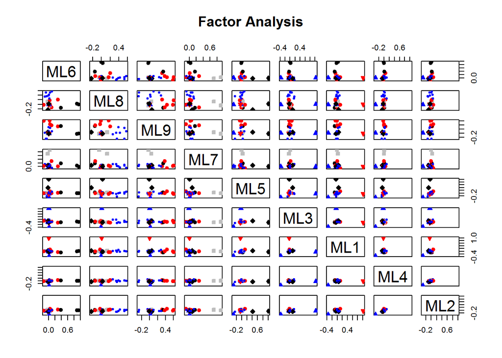

```r
factor.plot(fa(dat, nfactors=9, rotate="oblimin", fm="ml"))
```

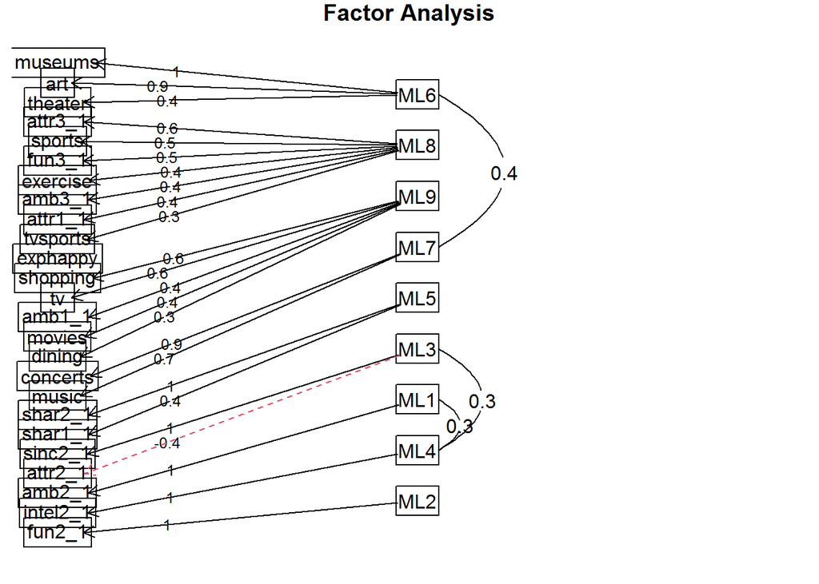

```r
fa.diagram(fa(dat, nfactors=9, rotate="oblimin", fm="ml"))
```

In this FA cumulitive var = 0.55, so it i better that previous one(=0.29). Here is an improvement. Tucker L. I. = 0.689. Better than previous one (0.251). RMSEA I. = 0.108. Better than previous one (0.133). (Decreased)

Here is an improvement.

List of unique factors with <+-0.3

- Ftr№1: amb2_1 1.02

*Opinion that Ambitiousness is what the opposite sex looks for on a date.*

- Ftr№2: fun2_1 0.99

*Opinion that Fun is what the opposite sex looks for on a date.*

- Ftr№3: attr2_1 -0.38 / sinc2_1 1.03

*Opinion that Attractiveness and Sincereness is what the opposite sex looks for on a date*

- Ftr№4: intel2_1 1.03

*Opinion that Intelligence is what the opposite sex looks for on a date*

- Ftr№5: shar1_1 0.41 / shar2_1 1.01

*Opinion that Shared interests is what the opposite sex looks for on a date // as well as share interets is what respondent looks for on a date with opposite sex*

- Ftr№6: museums 0.96 / art 0.90 / theater 0.39

*Cultural consumption*

- Ftr№7: concerts 0.92 / music 0.71

*Musical consumption*

- Ftr№8: sports 0.53 / tvsports 0.34 / exercise 0.42 / attr1_1 0.36 / attr3_1 0.57 / fun3_1 0.53 / amb3_1 0.40

*Self evaluation as well as spending of free time*

- Ftr№9: dining 0.32 / tv 0.59 / theater 0.34 / movies 0.38 / shopping 0.61 / amb1_1 0.43

*Spending of free time as well as ambitiousness is what respondent is looking for on a date with opposite sex*